# Clinical Data Exploration

# Variables covariation

## Demographic vs clinical

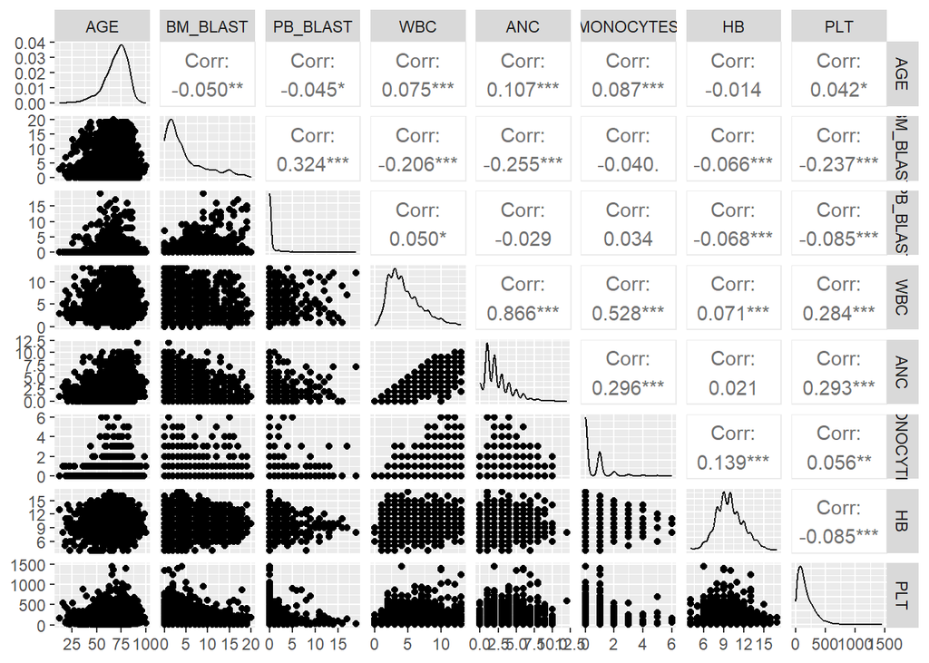

```r
ggpairs(clinical_all[, c("AGE", clin_vars)])
```

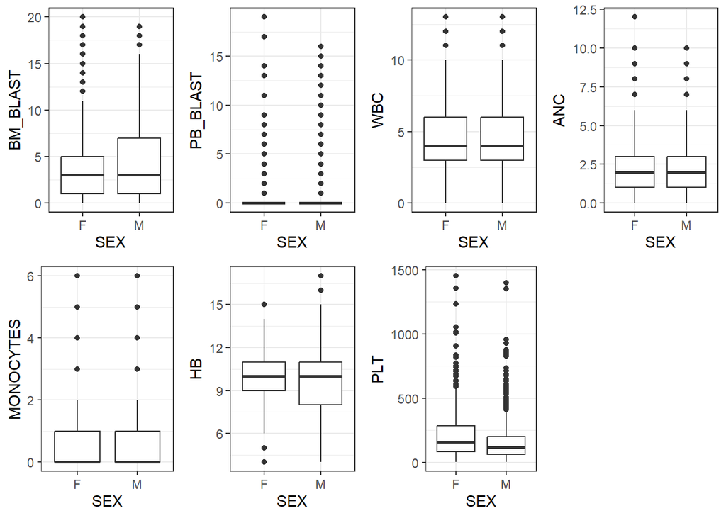

```r
plot_grid(plotlist =
            lapply(clin_vars, function(var){
   ggplot(clinical_all, aes(x = SEX, y = .data[[var]])) +
    geom_boxplot() +
    theme_bw()
}), nrow = 2)
```

```r
summary(lm(PLT ~ SEX, clinical_all))
```

```
##
## Call:
## lm(formula = PLT ~ SEX, data = clinical_all)
##
## Residuals:
##     Min      1Q  Median      3Q     Max
## -197.33  -99.33  -38.33   62.67 1248.67
##
## Coefficients:
##             Estimate Std. Error t value Pr(>|t|)
## (Intercept)  202.325      4.368  46.322   <2e-16 ***
## SEXM         -50.690      5.643  -8.983   <2e-16 ***
## ---
## Signif. codes:  0 '***' 0.001 '**' 0.01 '*' 0.05 '.' 0.1 ' ' 1
##
## Residual standard error: 147.3 on 2837 degrees of freedom
##   (118 observations deleted due to missingness)
## Multiple R-squared:  0.02766,    Adjusted R-squared:  0.02732
## F-statistic:  80.7 on 1 and 2837 DF,  p-value: < 2.2e-16
```

Among the clinical variables, we observed correlation between the blood cell counts (WBC, ANC and MONOCYTES). Age is not correlated with any clinical variable. Female had slightly higher platelet levels.

## Demographic vs cytogenetics

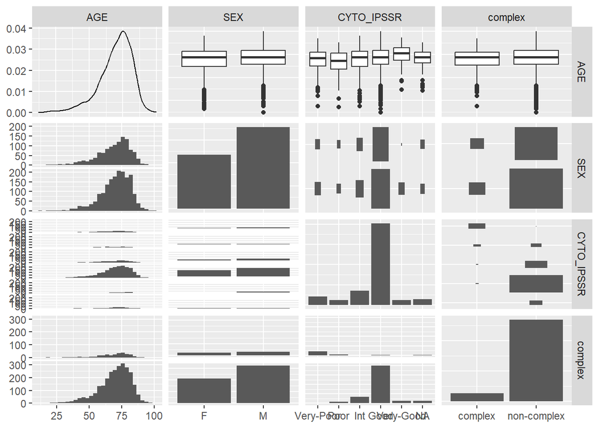

```r
ggpairs(clinical_all[, c(demo_vars, "CYTO_IPSSR", "complex")])
```

There is no correlation between age and sex and cytogenetics.

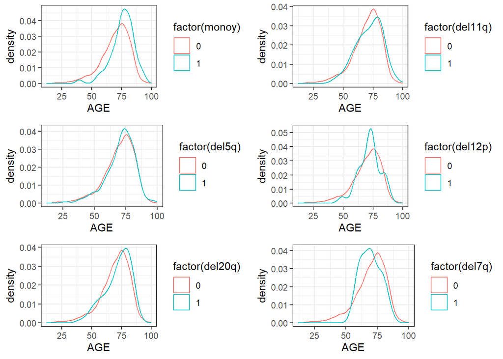

```r
plot_grid(plotlist =
            lapply(kar_events[1:6], function(var){
   ggplot(clinical_all, aes(color = factor(.data[[var]]), x = AGE)) +
    geom_density() +
    theme_bw()
}), nrow = 3)
```

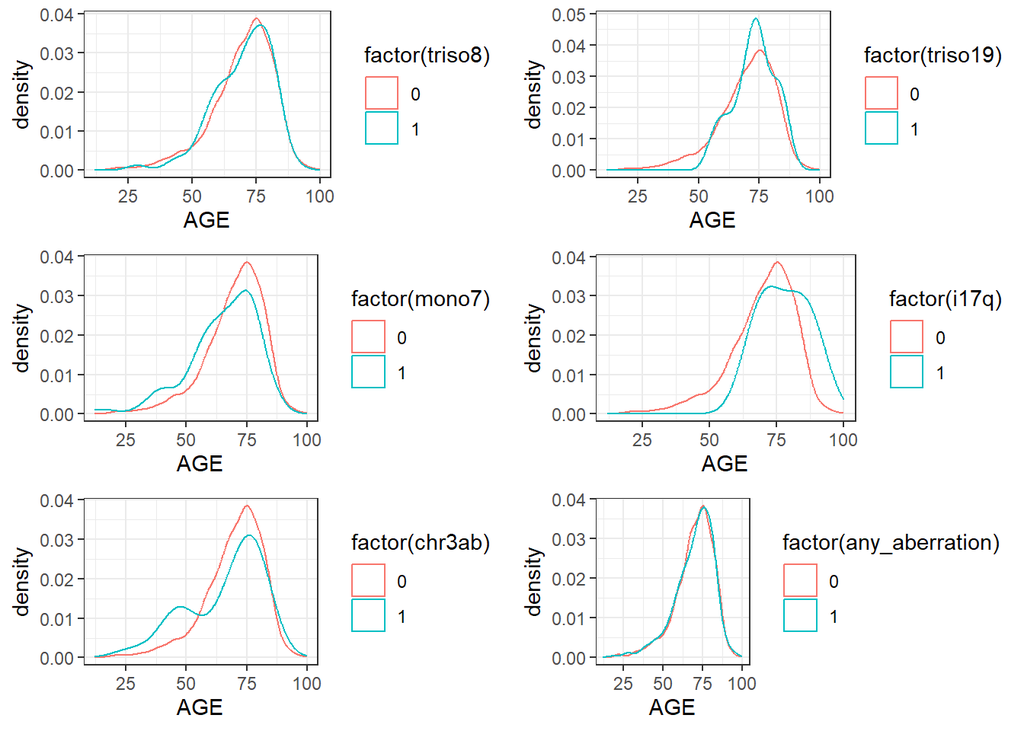

```r
plot_grid(plotlist =
            lapply(kar_events[7:12], function(var){
   ggplot(clinical_all, aes(color = factor(.data[[var]]), x = AGE)) +
    geom_density() +
    theme_bw()
}), nrow = 3)
```

```r
summary(glm(del7q ~ AGE, clinical_all, family = "binomial" ))
```

```
##
## Call:
## glm(formula = del7q ~ AGE, family = "binomial", data = clinical_all)
##
## Deviance Residuals:
##     Min       1Q   Median       3Q      Max
## -0.1473  -0.1415  -0.1406  -0.1399   3.0468
##
## Coefficients:
##              Estimate Std. Error z value Pr(>|z|)
## (Intercept) -4.499000   1.064565  -4.226 2.38e-05 ***
## AGE         -0.001563   0.015069  -0.104    0.917
## ---
## Signif. codes:  0 '***' 0.001 '**' 0.01 '*' 0.05 '.' 0.1 ' ' 1
##
## (Dispersion parameter for binomial family taken to be 1)
##
##     Null deviance: 325.55  on 2936  degrees of freedom
## Residual deviance: 325.54  on 2935  degrees of freedom
##   (20 observations deleted due to missingness)
## AIC: 329.54
##
## Number of Fisher Scoring iterations: 7
```

```r
summary(glm(monoy ~ AGE, clinical_all, family = "binomial" ))
```

```
##
## Call:
## glm(formula = monoy ~ AGE, family = "binomial", data = clinical_all)
##
## Deviance Residuals:
##     Min       1Q   Median       3Q      Max
## -0.5608  -0.3241  -0.2709  -0.2149   3.1517
##
## Coefficients:
##             Estimate Std. Error z value Pr(>|z|)
## (Intercept) -6.99891    0.76669  -9.129  < 2e-16 ***
## AGE          0.05229    0.01010   5.179 2.23e-07 ***
## ---
## Signif. codes:  0 '***' 0.001 '**' 0.01 '*' 0.05 '.' 0.1 ' ' 1
##
## (Dispersion parameter for binomial family taken to be 1)
##
##     Null deviance: 977.08  on 2936  degrees of freedom
## Residual deviance: 945.25  on 2935  degrees of freedom
##   (20 observations deleted due to missingness)
## AIC: 949.25
##
## Number of Fisher Scoring iterations: 6
```

```r
summary(glm(del12p ~ AGE, clinical_all, family = "binomial" ))
```

```
##
## Call:
## glm(formula = del12p ~ AGE, family = "binomial", data = clinical_all)
##
## Deviance Residuals:
##     Min       1Q   Median       3Q      Max
## -0.1689  -0.1413  -0.1345  -0.1250   3.1884
##
## Coefficients:
##             Estimate Std. Error z value Pr(>|z|)
## (Intercept) -5.87782    1.28837  -4.562 5.06e-06 ***
## AGE          0.01635    0.01769   0.924    0.355
## ---
## Signif. codes:  0 '***' 0.001 '**' 0.01 '*' 0.05 '.' 0.1 ' ' 1
##
## (Dispersion parameter for binomial family taken to be 1)
##
##     Null deviance: 297.58  on 2936  degrees of freedom
## Residual deviance: 296.67  on 2935  degrees of freedom
##   (20 observations deleted due to missingness)
## AIC: 300.67
##
## Number of Fisher Scoring iterations: 7
```

```r
summary(glm(mono7 ~ AGE, clinical_all, family = "binomial" ))
```

```
##
## Call:
## glm(formula = mono7 ~ AGE, family = "binomial", data = clinical_all)
##
## Deviance Residuals:
##     Min       1Q   Median       3Q      Max
## -0.5726  -0.3062  -0.2714  -0.2504   2.7267
##
## Coefficients:
##              Estimate Std. Error z value Pr(>|z|)
## (Intercept) -1.287771   0.435368  -2.958   0.0031 **
## AGE         -0.027331   0.006495  -4.208 2.58e-05 ***
## ---
## Signif. codes:  0 '***' 0.001 '**' 0.01 '*' 0.05 '.' 0.1 ' ' 1
##
## (Dispersion parameter for binomial family taken to be 1)
##
##     Null deviance: 1015.1  on 2936  degrees of freedom
## Residual deviance:  998.9  on 2935  degrees of freedom
##   (20 observations deleted due to missingness)
## AIC: 1002.9
##
## Number of Fisher Scoring iterations: 6
```

```r
summary(glm(chr3ab ~ AGE, clinical_all, family = "binomial" ))
```

```
##
## Call:
## glm(formula = chr3ab ~ AGE, family = "binomial", data = clinical_all)
##
## Deviance Residuals:
##     Min       1Q   Median       3Q      Max
## -0.2501  -0.1445  -0.1328  -0.1233   3.1523
##
## Coefficients:
##             Estimate Std. Error z value Pr(>|z|)
## (Intercept) -3.19321    0.91481  -3.491 0.000482 ***
## AGE         -0.02130    0.01352  -1.576 0.115051
## ---
## Signif. codes:  0 '***' 0.001 '**' 0.01 '*' 0.05 '.' 0.1 ' ' 1
##
## (Dispersion parameter for binomial family taken to be 1)
##
##     Null deviance: 316.30  on 2936  degrees of freedom
## Residual deviance: 314.02  on 2935  degrees of freedom
##   (20 observations deleted due to missingness)
## AIC: 318.02
##
## Number of Fisher Scoring iterations: 7
```

```r
summary(glm(triso19 ~ AGE, clinical_all, family = "binomial" ))
```

```
##
## Call:
## glm(formula = triso19 ~ AGE, family = "binomial", data = clinical_all)
##
## Deviance Residuals:
##     Min       1Q   Median       3Q      Max
## -0.1501  -0.1164  -0.1085  -0.0978   3.3188
##
## Coefficients:
##             Estimate Std. Error z value Pr(>|z|)
## (Intercept) -6.80483    1.66939  -4.076 4.58e-05 ***
## AGE          0.02324    0.02268   1.025    0.306
## ---
## Signif. codes:  0 '***' 0.001 '**' 0.01 '*' 0.05 '.' 0.1 ' ' 1
##
## (Dispersion parameter for binomial family taken to be 1)
##
##     Null deviance: 209.07  on 2936  degrees of freedom
## Residual deviance: 207.92  on 2935  degrees of freedom
##   (20 observations deleted due to missingness)
## AIC: 211.92
##
## Number of Fisher Scoring iterations: 8
```

```r
summary(glm(any_aberration ~ AGE, clinical_all, family = "binomial" ))
```

```
##
## Call:
## glm(formula = any_aberration ~ AGE, family = "binomial", data = clinical_all)
##
## Deviance Residuals:
##     Min       1Q   Median       3Q      Max
## -0.9869  -0.9601  -0.9547   1.4097   1.4283
##
## Coefficients:
##              Estimate Std. Error z value Pr(>|z|)
## (Intercept) -0.445503   0.220324  -2.022   0.0432 *
## AGE         -0.001299   0.003111  -0.418   0.6762
## ---
## Signif. codes:  0 '***' 0.001 '**' 0.01 '*' 0.05 '.' 0.1 ' ' 1
##
## (Dispersion parameter for binomial family taken to be 1)
##
##     Null deviance: 3867.8  on 2936  degrees of freedom
## Residual deviance: 3867.7  on 2935  degrees of freedom
##   (20 observations deleted due to missingness)
## AIC: 3871.7
##
## Number of Fisher Scoring iterations: 4
```

Karyotipic aberrations are not related with age. LOY is increased in older patients while monosomies 7 is associated with younger patients.

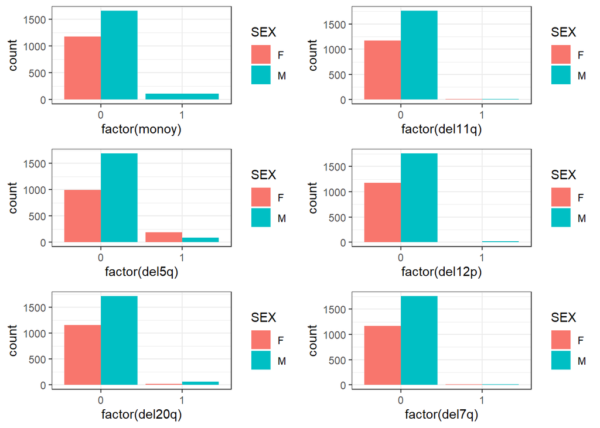

```r
plot_grid(plotlist =
            lapply(kar_events[1:6], function(var){
   ggplot(clinical_all, aes(x = factor(.data[[var]]), fill = SEX)) +
    geom_bar(position = "dodge") +
    theme_bw()
}), nrow = 3)
```

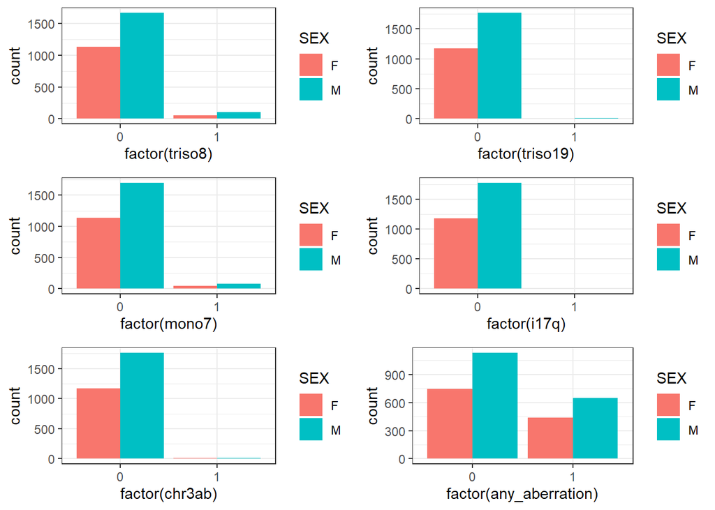

```r
plot_grid(plotlist =
            lapply(kar_events[7:12], function(var){
   ggplot(clinical_all, aes(x = factor(.data[[var]]), fill = SEX)) +
    geom_bar(position = "dodge") +
    theme_bw()
}), nrow = 3)
```

```r
fisher.test(table(clinical_all$del5q, clinical_all$SEX))
```

```
##
##  Fisher's Exact Test for Count Data
##
## data:  table(clinical_all$del5q, clinical_all$SEX)
## p-value < 2.2e-16
## alternative hypothesis: true odds ratio is not equal to 1
## 95 percent confidence interval:
##  0.2048573 0.3549838
## sample estimates:
## odds ratio
##  0.2705085
```

```r
fisher.test(table(clinical_all$triso8, clinical_all$SEX))
```

```
##
##  Fisher's Exact Test for Count Data
##
## data:  table(clinical_all$triso8, clinical_all$SEX)
## p-value = 0.04519
## alternative hypothesis: true odds ratio is not equal to 1
## 95 percent confidence interval:
##  0.9990378 2.0414539
## sample estimates:
## odds ratio
##   1.420318
```

```r
fisher.test(table(clinical_all$any_aberration, clinical_all$SEX))
```

```
##
##  Fisher's Exact Test for Count Data
##
## data:  table(clinical_all$any_aberration, clinical_all$SEX)
## p-value = 0.697
## alternative hypothesis: true odds ratio is not equal to 1
## 95 percent confidence interval:
##  0.8301744 1.1332012
## sample estimates:
## odds ratio
##  0.9697636
```

del5q is more frequent in women than in men, while trisomy 8 is more likely in men. Having any type of aberration is not associated with sex.

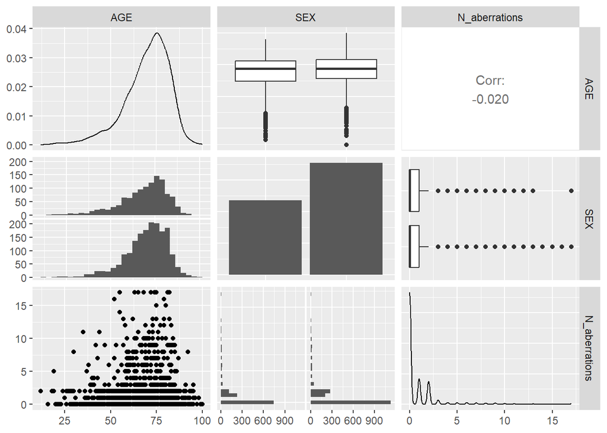

```r
ggpairs(clinical_all[, c(demo_vars, "N_aberrations")])
```

There is no correlation between age or sex and the number of karyotipic aberrations.

## Demographic vs subtypes

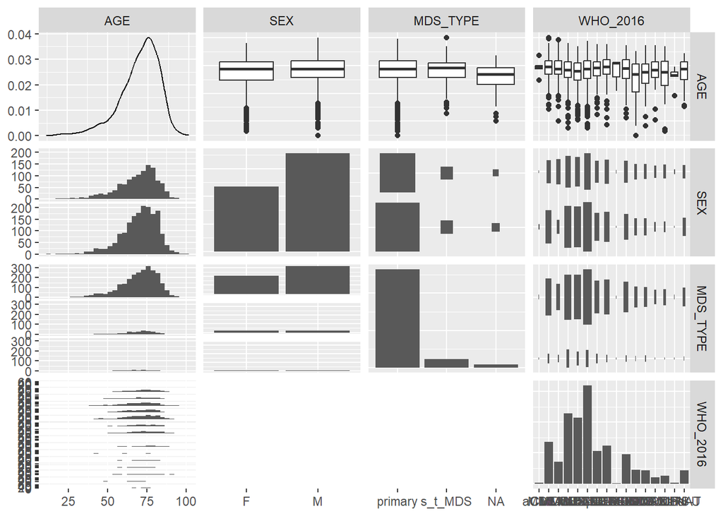

```r
ggpairs(clinical_all[, c(demo_vars, mds_types)])
```

There might be an association between age and WHO subtypes.

## Demographic vs risks

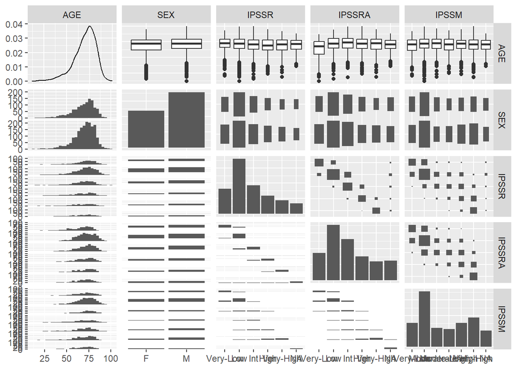

```r
ggpairs(clinical_all[, c(demo_vars, "IPSSR", "IPSSRA", "IPSSM")])
```

There is no association between IPSS categories and sex or age.

## Demographic vs survival

### Overall Survival

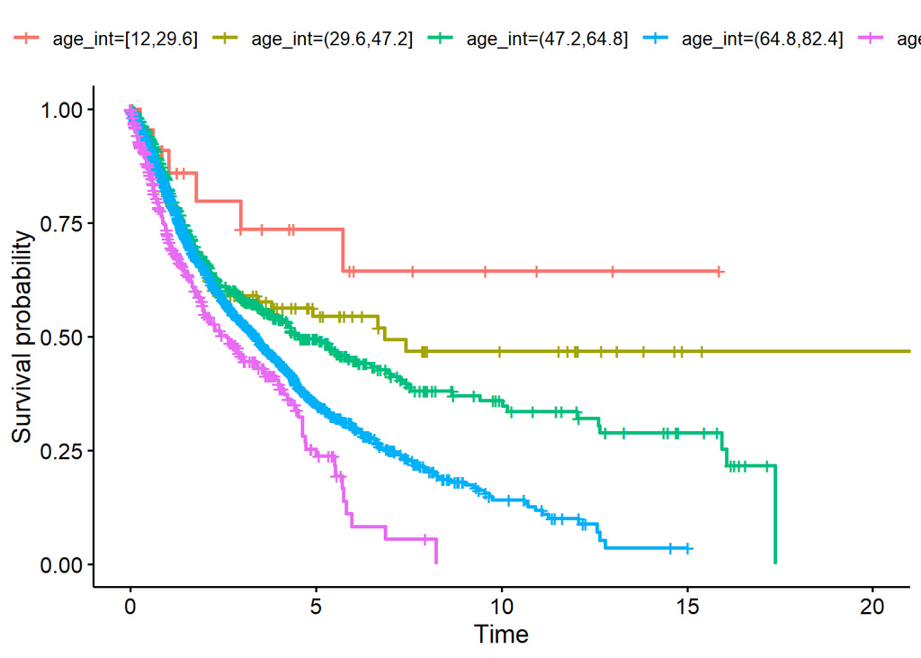

```r
clin_age <- mutate(clinical_all, age_int = cut_interval(AGE, 5))
os_age <- survfit(Surv(OS_YEARS,OS_STATUS) ~ age_int, clin_age)
ggsurvplot(os_age, data = clin_age)
```

```r
coxph(Surv(OS_YEARS,OS_STATUS) ~ AGE, clinical_all)
```

```
## Call:
## coxph(formula = Surv(OS_YEARS, OS_STATUS) ~ AGE, data = clinical_all)
##
##         coef exp(coef) se(coef)     z      p
## AGE 0.021505  1.021738 0.002507 8.578 <2e-16
##
## Likelihood ratio test=80.04  on 1 df, p=< 2.2e-16
## n= 2807, number of events= 1352
##    (150 observations deleted due to missingness)
```

Older patients had worse survival.

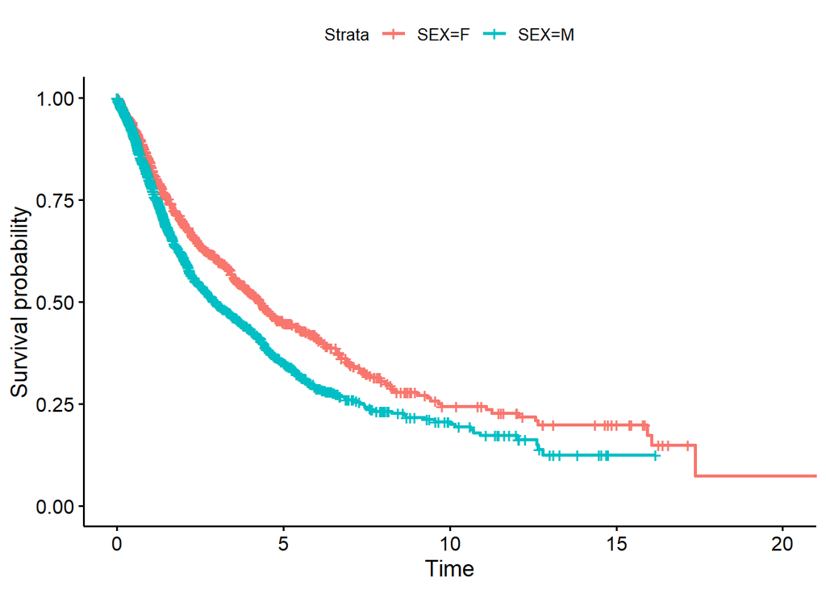

```r
os_sex <- survfit(Surv(OS_YEARS,OS_STATUS) ~ SEX, clinical_all)
ggsurvplot(os_sex, data = clinical_all)
```

```r
coxph(Surv(OS_YEARS,OS_STATUS) ~ SEX, clinical_all)
```

```
## Call:
## coxph(formula = Surv(OS_YEARS, OS_STATUS) ~ SEX, data = clinical_all)
##
##         coef exp(coef) se(coef)     z       p
## SEXM 0.27557   1.31728  0.05656 4.872 1.1e-06
##
## Likelihood ratio test=24.25  on 1 df, p=8.459e-07
## n= 2811, number of events= 1354
##    (146 observations deleted due to missingness)
```

Men had worse survival than women.

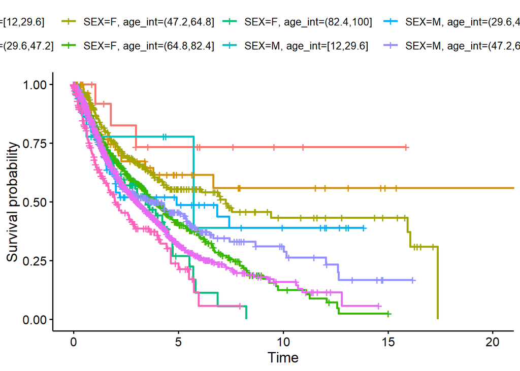

```r
os_demo <- survfit(Surv(OS_YEARS,OS_STATUS) ~ SEX + age_int, clin_age)
ggsurvplot(os_demo, data = clin_age)
```

```r
coxph(Surv(OS_YEARS,OS_STATUS) ~ SEX + AGE, clinical_all)
```

```
## Call:
## coxph(formula = Surv(OS_YEARS, OS_STATUS) ~ SEX + AGE, data = clinical_all)
##
##          coef exp(coef) se(coef)     z        p
## SEXM 0.256025  1.291785 0.056609 4.523 6.11e-06
## AGE  0.021186  1.021412 0.002519 8.411  < 2e-16
##
## Likelihood ratio test=100.9  on 2 df, p=< 2.2e-16
## n= 2807, number of events= 1352
##    (150 observations deleted due to missingness)
```

Women had higher survival at all ages.

### Acute Myeloid Leukemia transformation

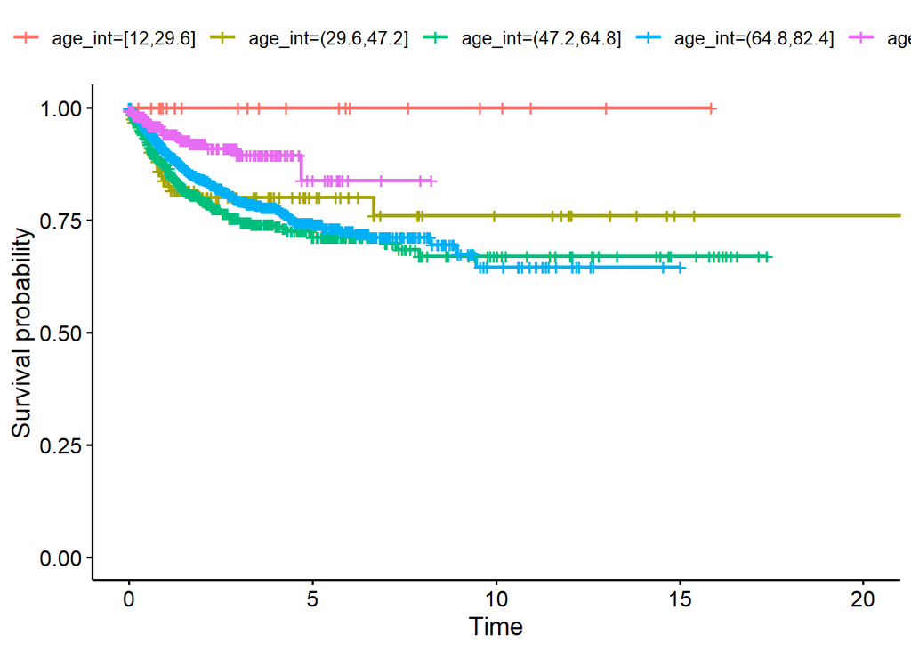

```r
aml_age <- survfit(Surv(AMLt_YEARS,AMLt_STATUS) ~ age_int, clin_age)
ggsurvplot(aml_age, data = clin_age)
```

```r
coxph(Surv(AMLt_YEARS,AMLt_STATUS) ~ AGE, clinical_all)
```

```
## Call:
## coxph(formula = Surv(AMLt_YEARS, AMLt_STATUS) ~ AGE, data = clinical_all)
##
##          coef exp(coef)  se(coef)      z      p
## AGE -0.007902  0.992129  0.003747 -2.109 0.0349
##
## Likelihood ratio test=4.29  on 1 df, p=0.03836
## n= 2632, number of events= 415
##    (325 observations deleted due to missingness)
```

Middle-age patients (47-80 yo) have the highest risk for Acute Myeloid Leukemia transformation.

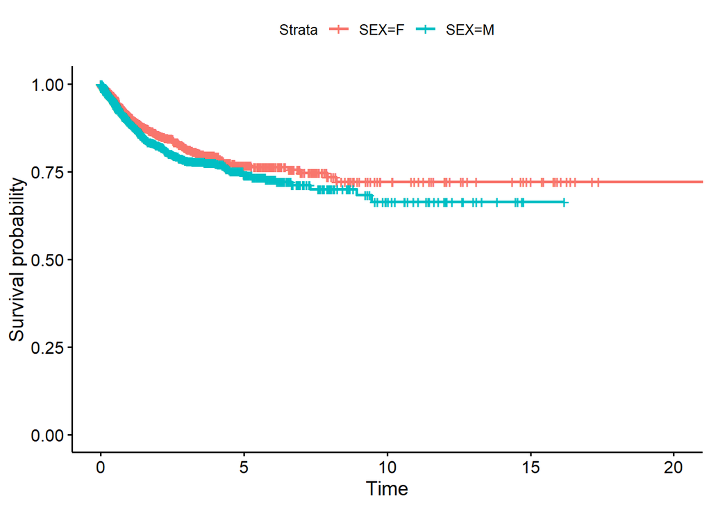

```r
aml_sex <- survfit(Surv(AMLt_YEARS,AMLt_STATUS) ~ SEX, clinical_all)
ggsurvplot(aml_sex, data = clinical_all)
```

```r
coxph(Surv(AMLt_YEARS,AMLt_STATUS) ~ SEX, clinical_all)
```

```
## Call:
## coxph(formula = Surv(AMLt_YEARS, AMLt_STATUS) ~ SEX, data = clinical_all)
##
##        coef exp(coef) se(coef)     z      p
## SEXM 0.1811    1.1986   0.1011 1.792 0.0732
##
## Likelihood ratio test=3.25  on 1 df, p=0.07139
## n= 2633, number of events= 415
##    (324 observations deleted due to missingness)
```

There were no differences between men and women for AML transformation.

### Leukemia-Free Survival

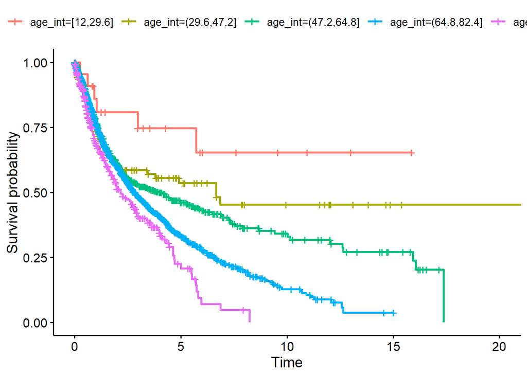

```r
lfs_age <- survfit(Surv(LFS_YEARS,LFS_STATUS) ~ age_int, clin_age)
ggsurvplot(lfs_age, data = clin_age)
```

```r
coxph(Surv(LFS_YEARS,LFS_STATUS) ~ AGE, clinical_all)
```

```
## Call:
## coxph(formula = Surv(LFS_YEARS, LFS_STATUS) ~ AGE, data = clinical_all)
##
##         coef exp(coef) se(coef)     z        p
## AGE 0.018923  1.019103 0.002462 7.685 1.53e-14
##
## Likelihood ratio test=63.86  on 1 df, p=1.334e-15
## n= 2615, number of events= 1351
##    (342 observations deleted due to missingness)
```

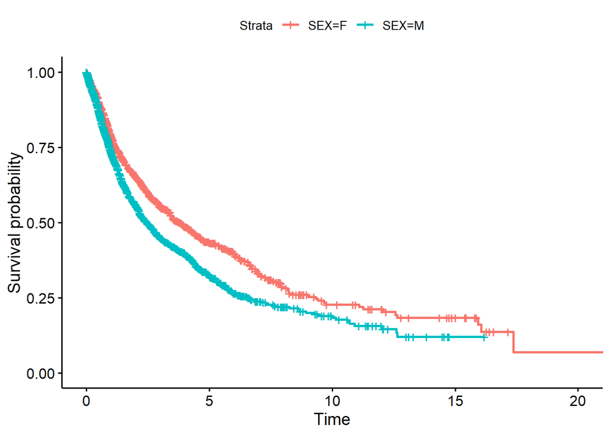

```r
lfs_sex <- survfit(Surv(LFS_YEARS,LFS_STATUS) ~ SEX, clinical_all)
ggsurvplot(lfs_sex, data = clinical_all)
```

```r
coxph(Surv(LFS_YEARS,LFS_STATUS) ~ SEX, clinical_all)
```

```
## Call:
## coxph(formula = Surv(LFS_YEARS, LFS_STATUS) ~ SEX, data = clinical_all)
##
##         coef exp(coef) se(coef)     z        p
## SEXM 0.27616   1.31806  0.05651 4.887 1.02e-06
##
## Likelihood ratio test=24.38  on 1 df, p=7.889e-07
## n= 2616, number of events= 1352
##    (341 observations deleted due to missingness)
```

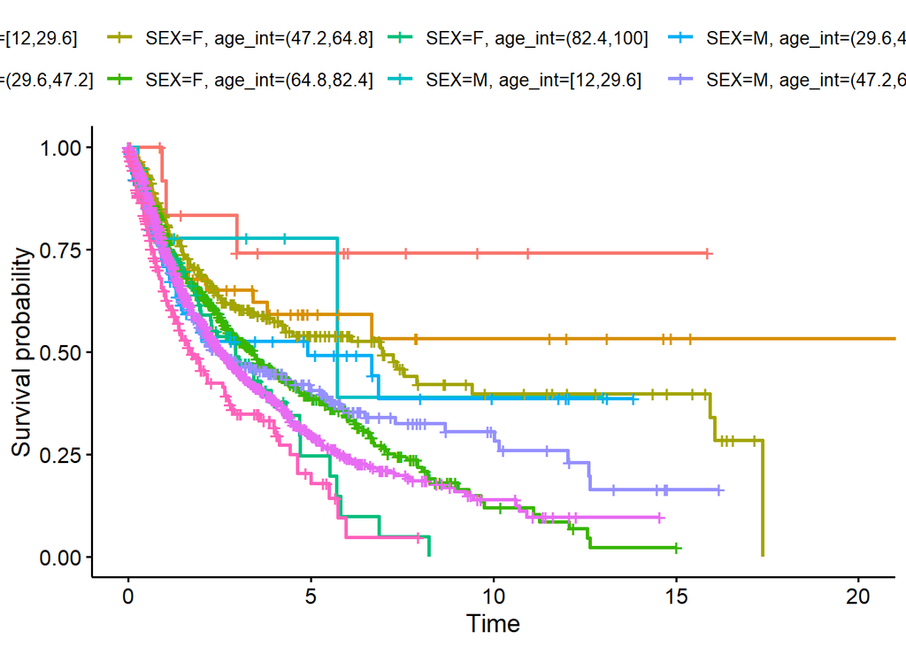

```r
lfs_demo <- survfit(Surv(LFS_YEARS,LFS_STATUS) ~ SEX + age_int, clin_age)
ggsurvplot(lfs_demo, data = clin_age)
```

```r
coxph(Surv(LFS_YEARS,LFS_STATUS) ~ SEX + AGE, clinical_all)
```

```
## Call:
## coxph(formula = Surv(LFS_YEARS, LFS_STATUS) ~ SEX + AGE, data = clinical_all)
##
##          coef exp(coef) se(coef)     z        p
## SEXM 0.257503  1.293695 0.056546 4.554 5.27e-06
## AGE  0.018580  1.018754 0.002475 7.506 6.10e-14
##
## Likelihood ratio test=85.01  on 2 df, p=< 2.2e-16
## n= 2615, number of events= 1351
##    (342 observations deleted due to missingness)
```

The differences between men and women are consistent for all the ages.

## Clinical vs cytogenetics

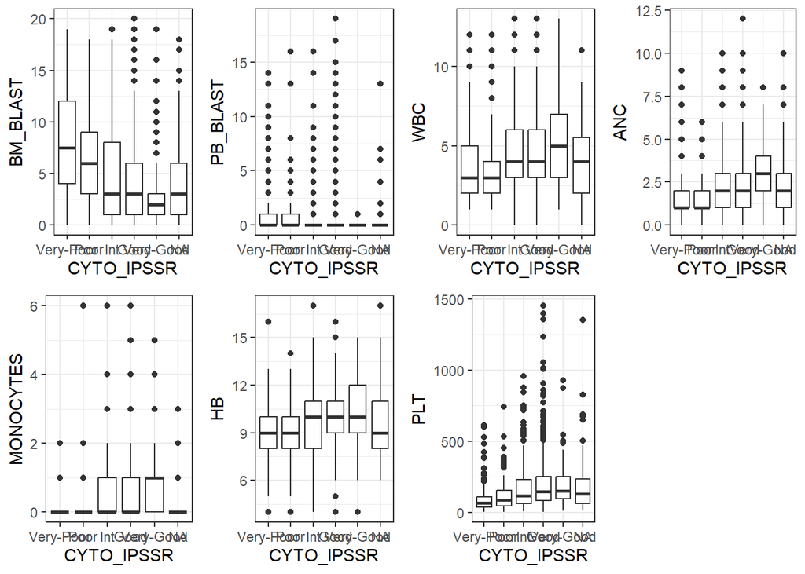

```r
plot_grid(plotlist =
            lapply(clin_vars, function(var){
   ggplot(clinical_all, aes(x = CYTO_IPSSR, y = .data[[var]])) +
    geom_boxplot() +
    theme_bw()
}), nrow = 2)
```

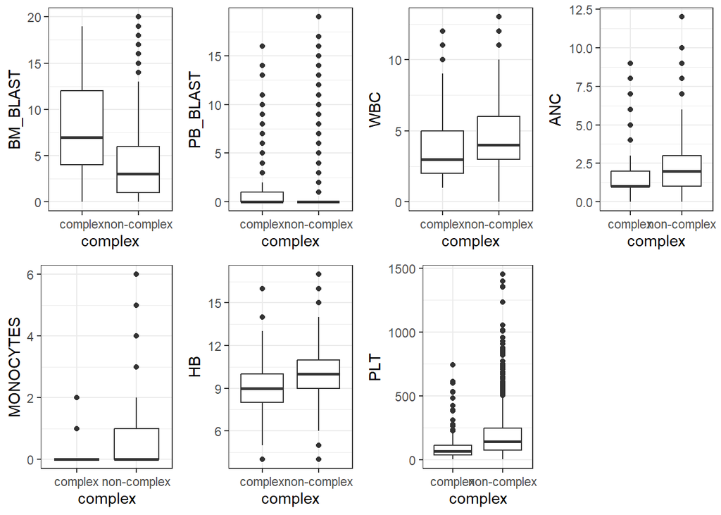

```r
plot_grid(plotlist =
            lapply(clin_vars, function(var){
   ggplot(clinical_all, aes(x = complex, y = .data[[var]])) +
    geom_boxplot() +
    theme_bw()
}), nrow = 2)
```

Cytogenetic measurements were reflected in cell types proportions.

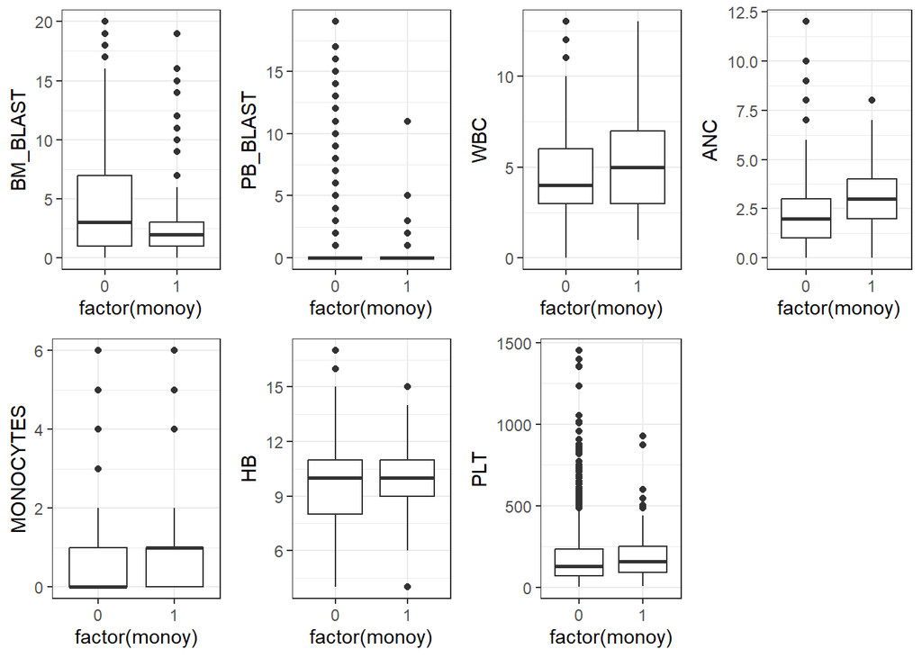

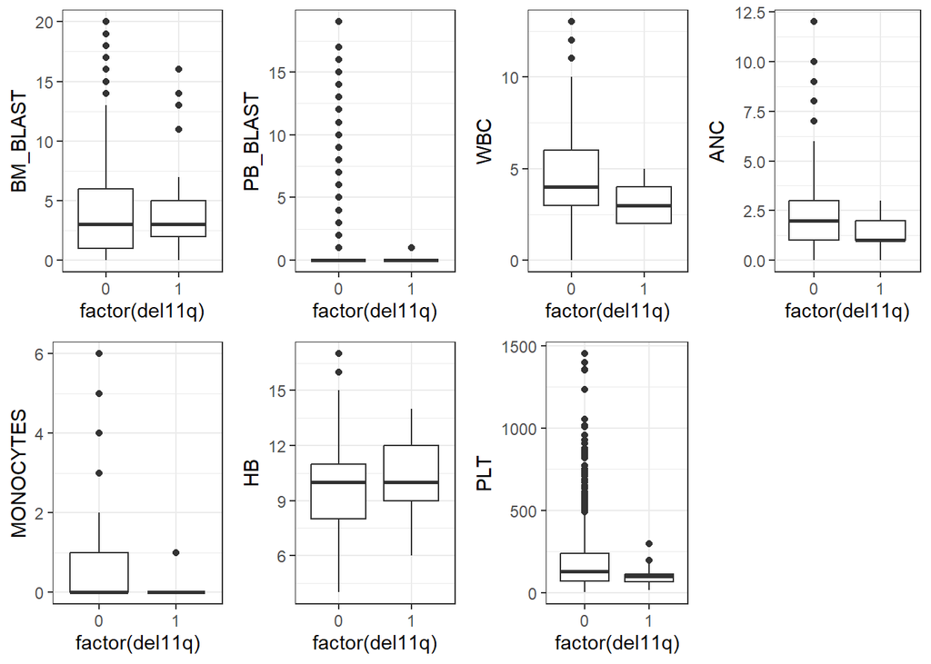

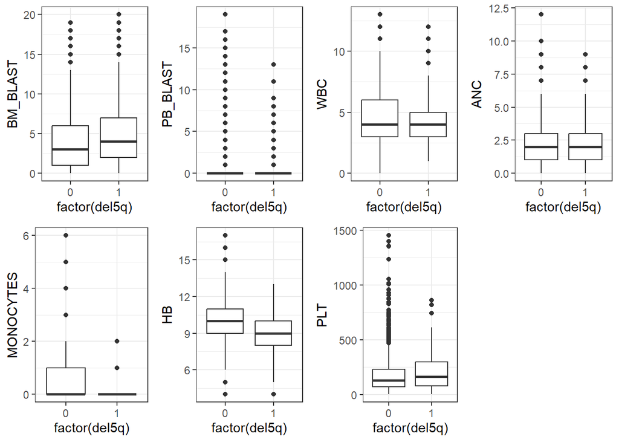

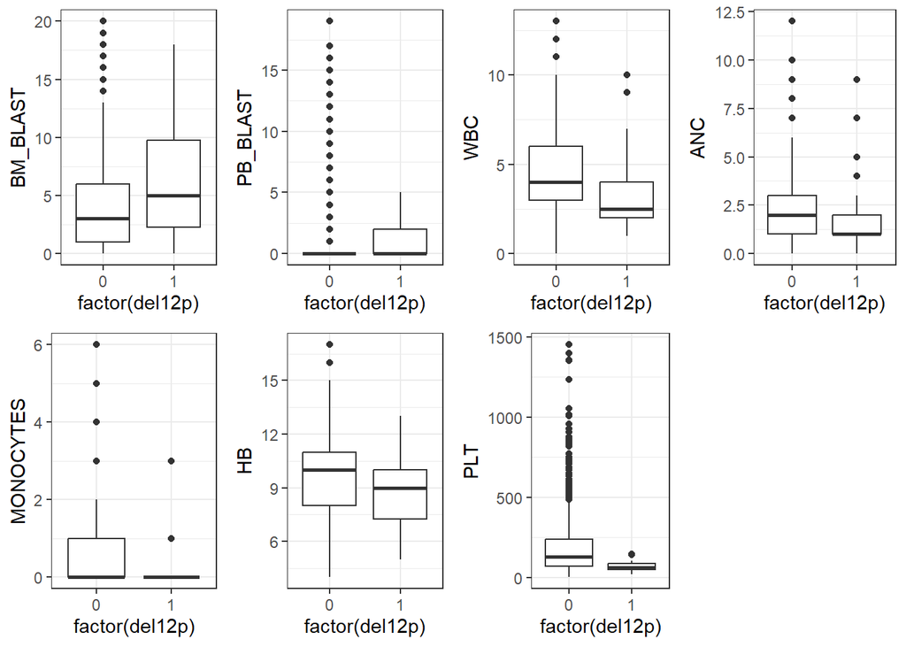

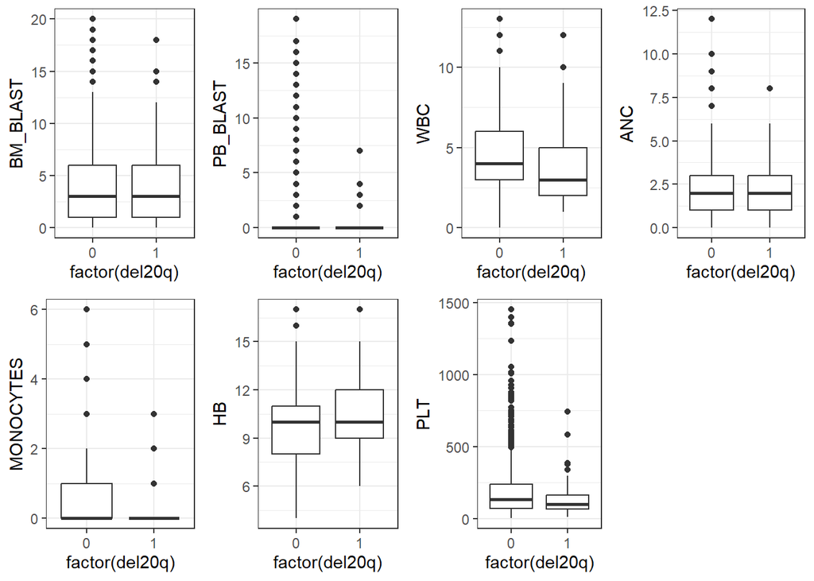

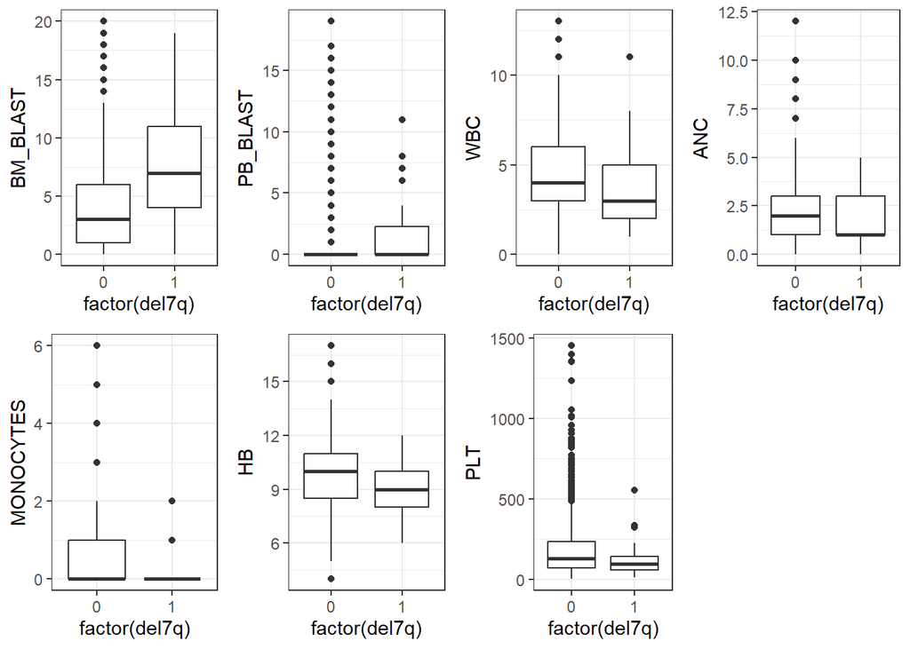

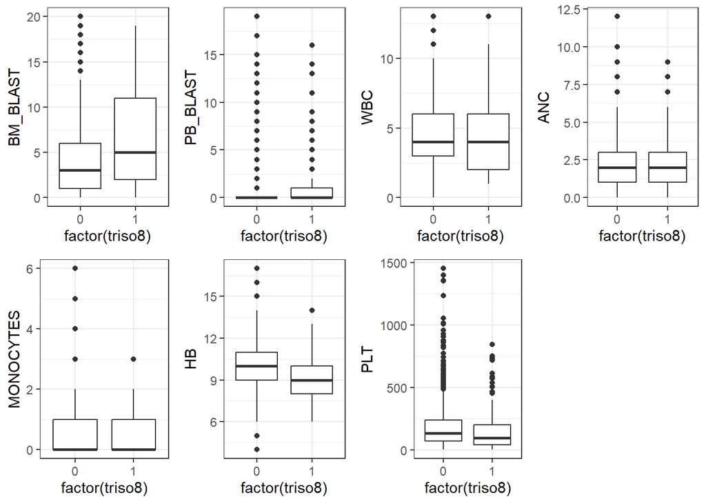

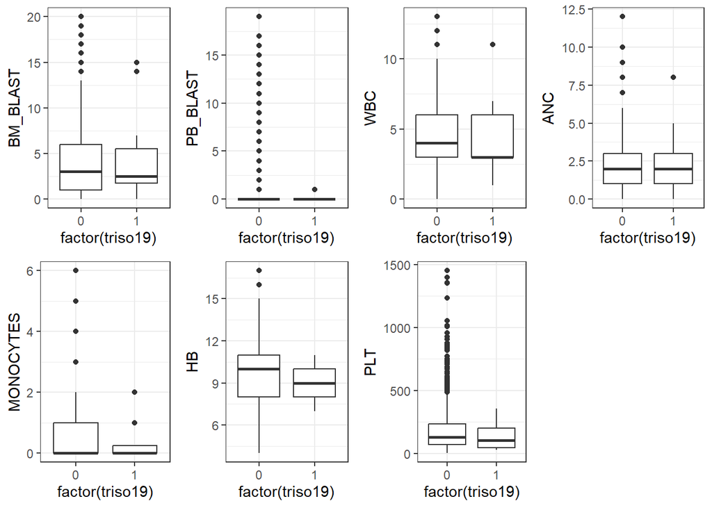

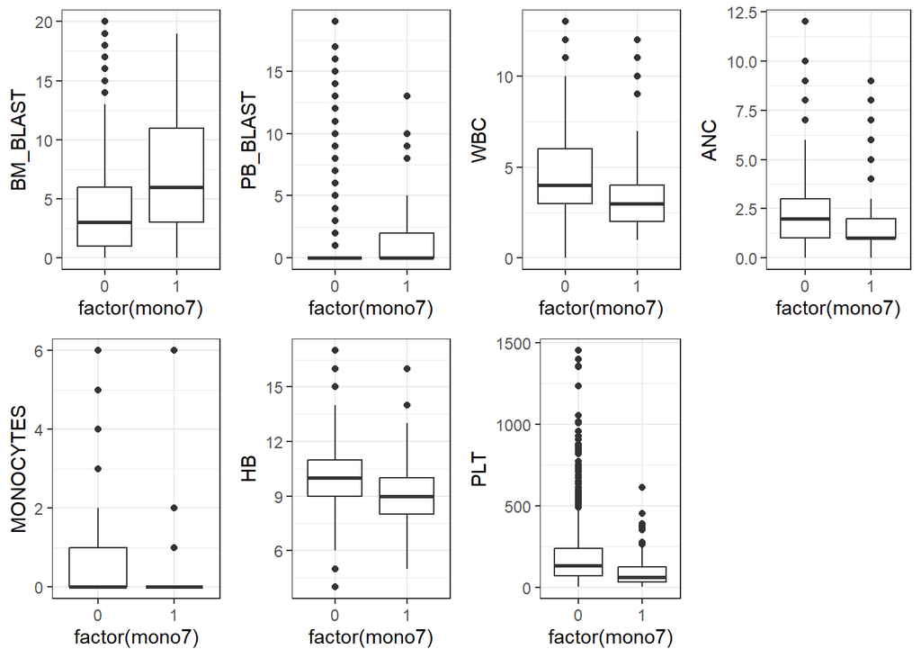

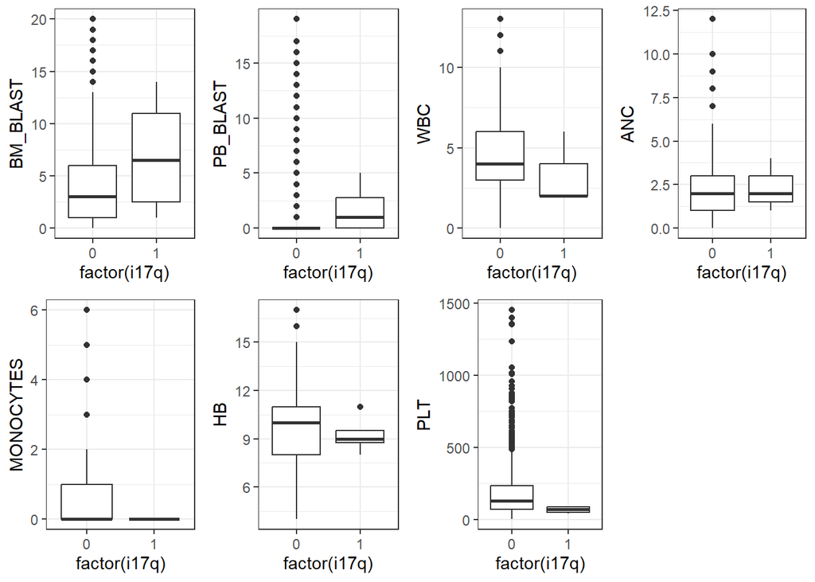

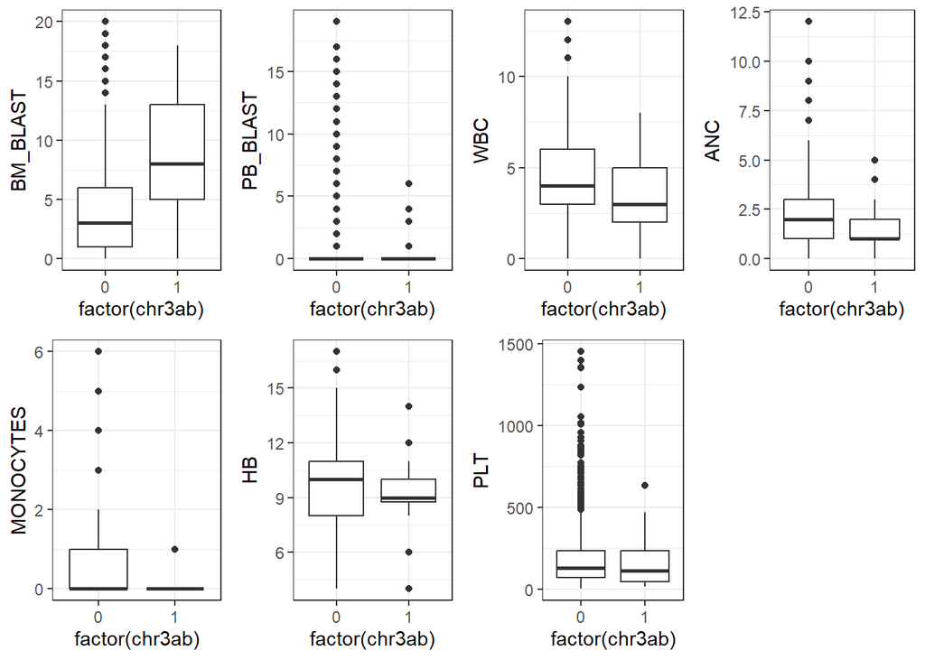

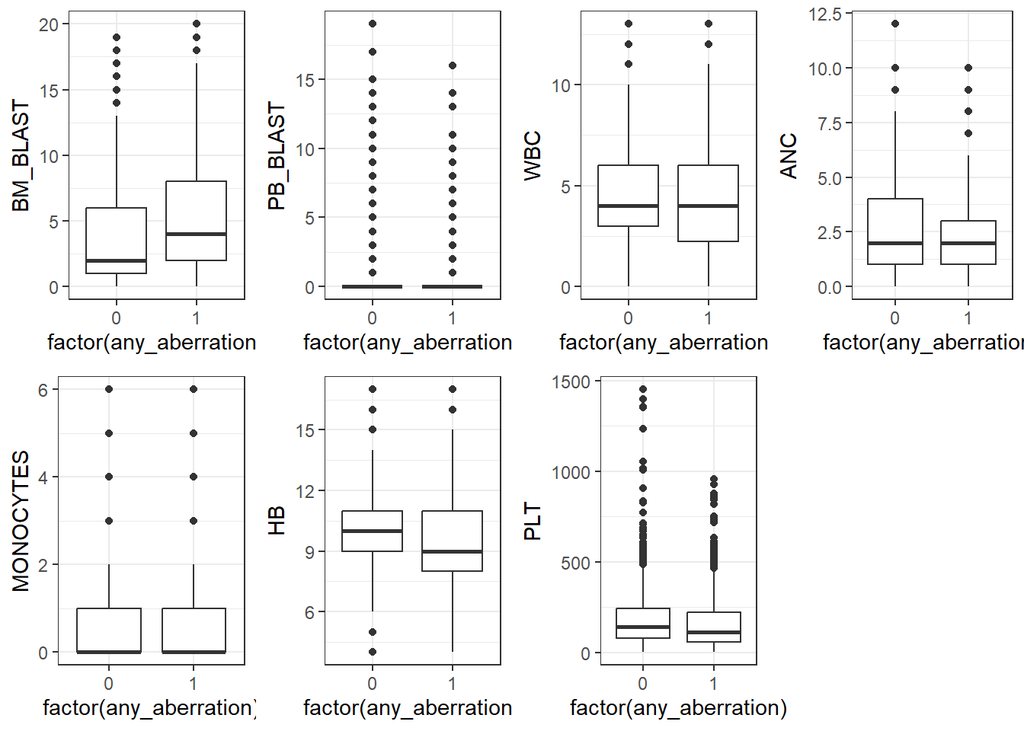

```r
lapply(kar_events, function(kar_var){
  plot_grid(plotlist =
            lapply(clin_vars, function(var){
   ggplot(clinical_all, aes(x = factor(.data[[kar_var]]), y = .data[[var]])) +
    geom_boxplot() +
    theme_bw()
  }), nrow = 2)
})
```

Cytogenetic events were reflected in cell types proportions.

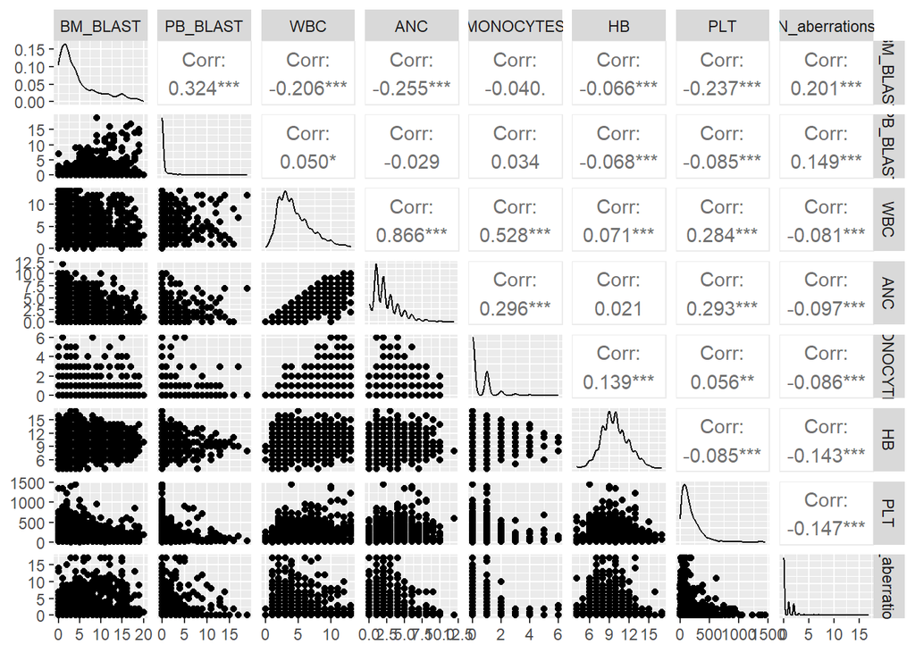

```r
ggpairs(clinical_all[, c(clin_vars, "N_aberrations")])
```

The number of aberrations was slighlty correlated with clinical measurements.

## Clinical vs subtypes

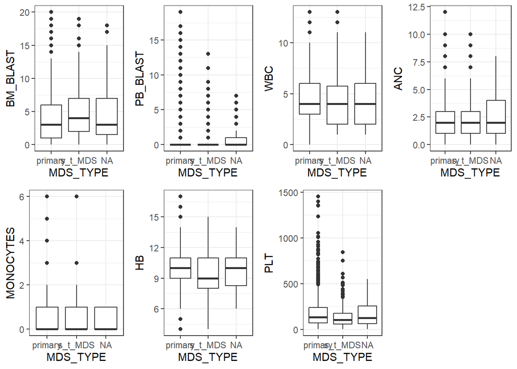

```r
plot_grid(plotlist =
            lapply(clin_vars, function(var){
   ggplot(clinical_all, aes(x = MDS_TYPE, y = .data[[var]])) +
    geom_boxplot() +
    theme_bw()
}), nrow = 2)
```

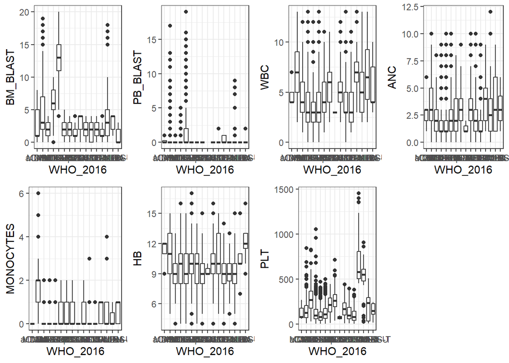

```r
plot_grid(plotlist =
            lapply(clin_vars, function(var){
   ggplot(clinical_all, aes(x = WHO_2016, y = .data[[var]])) +
    geom_boxplot() +
    theme_bw()
}), nrow = 2)
```

There is high correlation between WHO subtypes and clinical variables. Nonetheless, WHO subtypes are defined based on clinical variables.

## Clinical vs risks

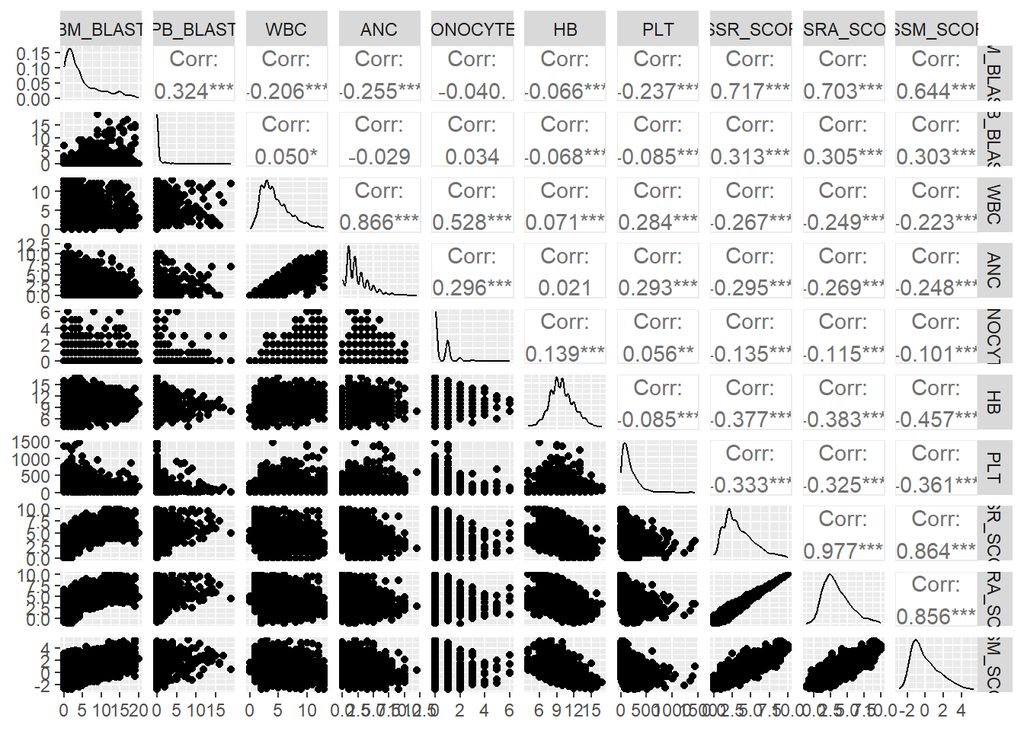

```r
ggpairs(clinical_all[, c(clin_vars, "IPSSR_SCORE", "IPSSRA_SCORE", "IPSSM_SCORE")])
```

Clinical variables are highly correlated with scores.

## Clinical vs Survival

```r
coxph(formula(paste("Surv(OS_YEARS,OS_STATUS) ~",  paste(clin_vars, collapse = "+"))),
              clinical_all)
```

```
## Call:
## coxph(formula = formula(paste("Surv(OS_YEARS,OS_STATUS) ~", paste(clin_vars,
##     collapse = "+"))), data = clinical_all)
##
##                 coef  exp(coef)   se(coef)       z        p
## BM_BLAST   0.0659740  1.0681989  0.0065934  10.006  < 2e-16
## PB_BLAST   0.0689790  1.0714137  0.0158539   4.351 1.36e-05
## WBC        0.0408215  1.0416661  0.0305072   1.338    0.181
## ANC       -0.0392446  0.9615155  0.0380622  -1.031    0.303
## MONOCYTES  0.0190755  1.0192586  0.0553007   0.345    0.730
## HB        -0.1919678  0.8253335  0.0158097 -12.142  < 2e-16
## PLT       -0.0017035  0.9982979  0.0002701  -6.307 2.84e-10
##
## Likelihood ratio test=357.2  on 7 df, p=< 2.2e-16
## n= 2042, number of events= 982
##    (915 observations deleted due to missingness)
```

Blast proportions, hemoglobin and platelets are associated with overall survival.

```r
coxph(formula(paste("Surv(AMLt_YEARS,AMLt_STATUS) ~",  paste(clin_vars, collapse = "+"))),
              clinical_all)
```

```
## Call:
## coxph(formula = formula(paste("Surv(AMLt_YEARS,AMLt_STATUS) ~",
##     paste(clin_vars, collapse = "+"))), data = clinical_all)
##
##                 coef  exp(coef)   se(coef)      z       p
## BM_BLAST   0.1403578  1.1506854  0.0106546 13.173 < 2e-16
## PB_BLAST   0.0259997  1.0263407  0.0271736  0.957 0.33867
## WBC        0.1579553  1.1711139  0.0510037  3.097 0.00196
## ANC       -0.2565123  0.7737455  0.0717481 -3.575 0.00035
## MONOCYTES -0.2283788  0.7958227  0.1096592 -2.083 0.03729
## HB        -0.0897623  0.9141485  0.0284401 -3.156 0.00160
## PLT       -0.0015971  0.9984042  0.0005266 -3.033 0.00242
##
## Likelihood ratio test=262.5  on 7 df, p=< 2.2e-16
## n= 1936, number of events= 299
##    (1021 observations deleted due to missingness)
```

Bone marrow blasts, whole blood counts and neutrophil counts are associated with AML transformation.

```r
coxph(formula(paste("Surv(LFS_YEARS,LFS_STATUS) ~",  paste(clin_vars, collapse = "+"))),
              clinical_all)
```

```
## Call:
## coxph(formula = formula(paste("Surv(LFS_YEARS,LFS_STATUS) ~",
##     paste(clin_vars, collapse = "+"))), data = clinical_all)
##
##                 coef  exp(coef)   se(coef)       z        p
## BM_BLAST   0.0816979  1.0851279  0.0065686  12.438  < 2e-16
## PB_BLAST   0.0541287  1.0556205  0.0163120   3.318 0.000906
## WBC        0.0578607  1.0595673  0.0299120   1.934 0.053068
## ANC       -0.0675891  0.9346444  0.0377004  -1.793 0.073006
## MONOCYTES -0.0076170  0.9924119  0.0559362  -0.136 0.891684
## HB        -0.1709966  0.8428245  0.0156299 -10.940  < 2e-16
## PLT       -0.0014197  0.9985813  0.0002632  -5.393 6.92e-08
##
## Likelihood ratio test=370  on 7 df, p=< 2.2e-16
## n= 1920, number of events= 994
##    (1037 observations deleted due to missingness)
```

Bone marrow proportions, hemoglobin and platelets are associated with leukemia free survival.

## Karyotype vs Survival

### Overall survival

```r
coxph(Surv(OS_YEARS,OS_STATUS) ~ any_aberration, clinical_all)
```

```
## Call:
## coxph(formula = Surv(OS_YEARS, OS_STATUS) ~ any_aberration, data = clinical_all)
##
##                   coef exp(coef) se(coef)     z      p
## any_aberration 0.46953   1.59924  0.05494 8.547 <2e-16
##
## Likelihood ratio test=71.08  on 1 df, p=< 2.2e-16
## n= 2811, number of events= 1354
##    (146 observations deleted due to missingness)
```

Having any karyotype aberration is associated with survival.

```r
coxph(Surv(OS_YEARS,OS_STATUS) ~ N_aberrations, clinical_all)
```

```
## Call:
## coxph(formula = Surv(OS_YEARS, OS_STATUS) ~ N_aberrations, data = clinical_all)
##
##                   coef exp(coef) se(coef)     z      p
## N_aberrations 0.162945  1.176972 0.008821 18.47 <2e-16
##
## Likelihood ratio test=215.2  on 1 df, p=< 2.2e-16
## n= 2811, number of events= 1354
##    (146 observations deleted due to missingness)
```

The number of aberrations is associated with worse survival.

```r
single_kar <- kar_events[kar_events != "any_aberration"]
coxph(formula(paste("Surv(OS_YEARS,OS_STATUS) ~",  paste(single_kar, collapse = "+"))),
              clinical_all)
```

```
## Call:
## coxph(formula = formula(paste("Surv(OS_YEARS,OS_STATUS) ~", paste(single_kar,
##     collapse = "+"))), data = clinical_all)
##
##             coef exp(coef) se(coef)      z        p
## monoy   -0.03469   0.96591  0.15241 -0.228 0.819959
## del11q   0.37153   1.44995  0.27031  1.374 0.169300
## del5q    0.17583   1.19223  0.08800  1.998 0.045727
## del12p   0.59372   1.81071  0.26004  2.283 0.022419
## del20q   0.03301   1.03356  0.15872  0.208 0.835253
## del7q    1.12334   3.07512  0.20534  5.471 4.48e-08
## triso8   0.66117   1.93706  0.10496  6.299 2.99e-10
## triso19  0.13172   1.14079  0.35818  0.368 0.713070
## mono7    0.94983   2.58526  0.11817  8.038 9.15e-16
## i17q     2.22873   9.28804  0.50238  4.436 9.15e-06
## chr3ab   0.83015   2.29366  0.23311  3.561 0.000369
##
## Likelihood ratio test=159.3  on 11 df, p=< 2.2e-16
## n= 2811, number of events= 1354
##    (146 observations deleted due to missingness)
```

Del5q, del12p, del7q, trisomy8, monosomy7, i17q and chr3 aberrations are associated with worse overall survival.

```r
coxph(Surv(OS_YEARS,OS_STATUS) ~ monoy, clinical_all, subset = SEX == "M")
```

```
## Call:
## coxph(formula = Surv(OS_YEARS, OS_STATUS) ~ monoy, data = clinical_all,
##     subset = SEX == "M")
##
##          coef exp(coef) se(coef)      z      p
## monoy -0.2853    0.7518   0.1532 -1.862 0.0626
##
## Likelihood ratio test=3.78  on 1 df, p=0.05194
## n= 1692, number of events= 856
##    (84 observations deleted due to missingness)
```

### Acute Myeloid Leukemia transformation

```r
coxph(Surv(AMLt_YEARS,AMLt_STATUS) ~ any_aberration, clinical_all)
```

```
## Call:
## coxph(formula = Surv(AMLt_YEARS, AMLt_STATUS) ~ any_aberration,
##     data = clinical_all)
##
##                   coef exp(coef) se(coef)     z        p
## any_aberration 0.64722   1.91023  0.09841 6.577 4.81e-11
##
## Likelihood ratio test=42.47  on 1 df, p=7.189e-11
## n= 2633, number of events= 415
##    (324 observations deleted due to missingness)
```

Having any karyotype aberration is associated with AML transformation.

```r
coxph(Surv(AMLt_YEARS,AMLt_STATUS) ~ N_aberrations, clinical_all)
```

```
## Call:
## coxph(formula = Surv(AMLt_YEARS, AMLt_STATUS) ~ N_aberrations,
##     data = clinical_all)
##
##                  coef exp(coef) se(coef)     z      p
## N_aberrations 0.14818   1.15972  0.01463 10.13 <2e-16
##
## Likelihood ratio test=66.83  on 1 df, p=2.962e-16
## n= 2633, number of events= 415
##    (324 observations deleted due to missingness)
```

The number of aberrations is associated with AML transformation.

```r
coxph(formula(paste("Surv(AMLt_YEARS,AMLt_STATUS) ~",  paste(single_kar, collapse = "+"))),
              clinical_all)
```

```
## Call:
## coxph(formula = formula(paste("Surv(AMLt_YEARS,AMLt_STATUS) ~",
##     paste(single_kar, collapse = "+"))), data = clinical_all)
##
##            coef exp(coef) se(coef)      z        p
## monoy   -0.5734    0.5636   0.3581 -1.601  0.10935
## del11q  -0.5405    0.5824   0.7111 -0.760  0.44718
## del5q    0.3882    1.4744   0.1444  2.688  0.00718
## del12p   0.8130    2.2547   0.3984  2.041  0.04128
## del20q  -0.6163    0.5399   0.3644 -1.691  0.09076
## del7q    1.2865    3.6202   0.2920  4.406 1.05e-05
## triso8   0.7458    2.1082   0.1730  4.310 1.63e-05
## triso19 -0.2831    0.7535   0.7139 -0.396  0.69175
## mono7    1.0235    2.7829   0.1910  5.358 8.42e-08
## i17q     1.5879    4.8933   1.0027  1.584  0.11328
## chr3ab   1.0419    2.8347   0.3598  2.896  0.00378
##
## Likelihood ratio test=95.92  on 11 df, p=1.142e-15
## n= 2633, number of events= 415
##    (324 observations deleted due to missingness)
```

```r
coxph(Surv(AMLt_YEARS,AMLt_STATUS) ~ monoy, clinical_all, subset = SEX == "M")
```

```
## Call:
## coxph(formula = Surv(AMLt_YEARS, AMLt_STATUS) ~ monoy, data = clinical_all,
##     subset = SEX == "M")
##
##          coef exp(coef) se(coef)      z      p
## monoy -0.8325    0.4349   0.3593 -2.317 0.0205
##
## Likelihood ratio test=7.05  on 1 df, p=0.007921
## n= 1581, number of events= 256
##    (195 observations deleted due to missingness)
```

LOY is protective of AMLt.

### Leukemia-Free Survival

```r
coxph(Surv(LFS_YEARS,LFS_STATUS) ~ any_aberration, clinical_all)
```

```
## Call:
## coxph(formula = Surv(LFS_YEARS, LFS_STATUS) ~ any_aberration,
##     data = clinical_all)
##
##                   coef exp(coef) se(coef)     z      p
## any_aberration 0.47509   1.60817  0.05496 8.644 <2e-16
##
## Likelihood ratio test=72.76  on 1 df, p=< 2.2e-16
## n= 2616, number of events= 1352
##    (341 observations deleted due to missingness)
```

Having any karyotype aberration is associated with Leukemia Free Survival (LFS).

```r
coxph(Surv(LFS_YEARS,LFS_STATUS) ~ N_aberrations, clinical_all)
```

```
## Call:
## coxph(formula = Surv(LFS_YEARS, LFS_STATUS) ~ N_aberrations,
##     data = clinical_all)
##
##                   coef exp(coef) se(coef)     z      p
## N_aberrations 0.150960  1.162950 0.008762 17.23 <2e-16
##
## Likelihood ratio test=192.6  on 1 df, p=< 2.2e-16
## n= 2616, number of events= 1352
##    (341 observations deleted due to missingness)
```

The number of aberrations is associated with having Leukemia.

```r
coxph(formula(paste("Surv(LFS_YEARS,LFS_STATUS) ~",  paste(single_kar, collapse = "+"))),
              clinical_all)
```

```
## Call:
## coxph(formula = formula(paste("Surv(LFS_YEARS,LFS_STATUS) ~",
##     paste(single_kar, collapse = "+"))), data = clinical_all)
##
##             coef exp(coef) se(coef)      z        p
## monoy   -0.02303   0.97723  0.15241 -0.151 0.879871
## del11q   0.19071   1.21010  0.28034  0.680 0.496336
## del5q    0.19528   1.21566  0.08802  2.219 0.026503
## del12p   0.53068   1.70008  0.25910  2.048 0.040548
## del20q  -0.03168   0.96882  0.15976 -0.198 0.842828
## del7q    1.00424   2.72984  0.20983  4.786 1.70e-06
## triso8   0.67777   1.96948  0.10376  6.532 6.49e-11
## triso19  0.24323   1.27537  0.33723  0.721 0.470743
## mono7    0.92803   2.52953  0.11892  7.804 6.01e-15
## i17q     1.98826   7.30283  0.50201  3.961 7.48e-05
## chr3ab   0.83387   2.30222  0.22726  3.669 0.000243
##
## Likelihood ratio test=152  on 11 df, p=< 2.2e-16
## n= 2616, number of events= 1352
##    (341 observations deleted due to missingness)
```

Del5q, del12p, del7q, trisomy8, monosomy7, i17q and chr3 aberrations are associated with LFS.

```r
coxph(Surv(LFS_YEARS,LFS_STATUS) ~ monoy, clinical_all, subset = SEX == "M")
```

```
## Call:
## coxph(formula = Surv(LFS_YEARS, LFS_STATUS) ~ monoy, data = clinical_all,
##     subset = SEX == "M")
##
##          coef exp(coef) se(coef)      z      p
## monoy -0.2739    0.7604   0.1532 -1.787 0.0739
##
## Likelihood ratio test=3.47  on 1 df, p=0.06252
## n= 1572, number of events= 850
##    (204 observations deleted due to missingness)
```